# Курсовой проект

# "2. Жесткие задачи Коши. Уравнения типа Ван-дер-Поля"

## 0. Условие

Рассмотрим автономные и неавтономные уравнения Ван-дер-Поля, а также уравнение Рэлея, описывающие колебательные процессы в электрических цепях.

а) Уравнение Ван-дер-Поля:

\begin{equation*} \begin{cases} \frac{dy_1}{dt} = -a (\frac{y_{1}^3}{3} - y_1) - a y_2,\\ \frac{dy_2}{dt} = -y_1; \end{cases} \end{equation*}

б) Уравнение Бонгоффера – Ван-дер-Поля:

\begin{equation*} \begin{cases} \frac{dy_1}{dt} = -a (\frac{y_{1}^3}{3} - y_1) + a y_2,\\ \frac{dy_2}{dt} = -y_1 - b y_2 + c; \end{cases} \end{equation*}

в) Неавтономное уравнение Ван-дер-Поля, траектория-«утка»:

\begin{equation*} \begin{cases} \frac{dy_1}{dt} = -a (\frac{y_{1}^3}{3} - y_1) + a y_2,\\ \frac{dy_2}{dt} = -y_1 + A cos(\omega t); \end{cases} \end{equation*}

г) Уравнение Рэлея:

\begin{equation*} x'' - a (1 - {x'}^2)x' + x = 0. \end{equation*}

В пунктах а), б), в) считать $1 \leq a \leq 10^3, (y_1)_0 = 2, (y_2)_0 = 0$. В пункте в) рассмотреть два случая:

\begin{equation} 0 < A < 1 \; и \; 1 < A < \sqrt{1 + \frac{1}{64 {\omega}^2}}, \: 0 \leq t \leq 200, \: 0 < c < 1. \end{equation}

$\underline{Задание.}$ 1) Провести исследование поведения численных решений систем а)-г) в зависимости от «большого» параметра $a$; в пункте в) – в зависимости от $\omega$.

2) Построить зависимости $y_1(𝑡), \: y_2(t), \: y_2(y_1)$.

3) Использовать явные методы Рунге-Кутты 1-го и 4-го порядков точности, неявный метод (Хаммера-Холлинсворта).

4) Исследовать зависимость численного решения от шага интегрирования $\tau$ (сходимость в сетке).

## 1. Явный метод Рунге-Кутта 1-го порядка

### 1.1. Уравнение Ван-дер-Поля

а) Уравнение Ван-дер-Поля:

\begin{equation*} \begin{cases} \frac{dy_1}{dt} = -a (\frac{y_{1}^3}{3} - y_1) - a y_2,\\ \frac{dy_2}{dt} = -y_1. \end{cases} \end{equation*}

Сделаем замену: $u = y_1, v = y_2$. Используем явный метод Эйлера:

\begin{equation*} u_{k+1} = u_k + \tau \cdot f(x_k, y_k). \end{equation*}

Исходную систему можно преобразовать к виду:

\begin{equation*} \begin{cases} \frac{u_{n+1} - u_n}{\tau} = -a (\frac{{u_n}^3}{3} - u_n) -a v_n,\\ \frac{v_{n+1} - v_n}{\tau} = -u_n. \end{cases} \end{equation*}

Решая данную систему получим выражения вида: $u_{n+1} = f(u_n, v_n), v_{n+1} = g(u_n, v_n)$. Имеем линейную систему:

\begin{equation*} \begin{cases} u_{n+1} = u_n - a \tau (\frac{{u_n}^3}{3} - u_n) - a \tau v_n;\\ v_{n+1} = v_n - \tau u_n; \end{cases} \end{equation*}

и $u(0) = u_0 = 2, \; v(0) = v_0 = 0$. Получили искомые формулы решения системы.

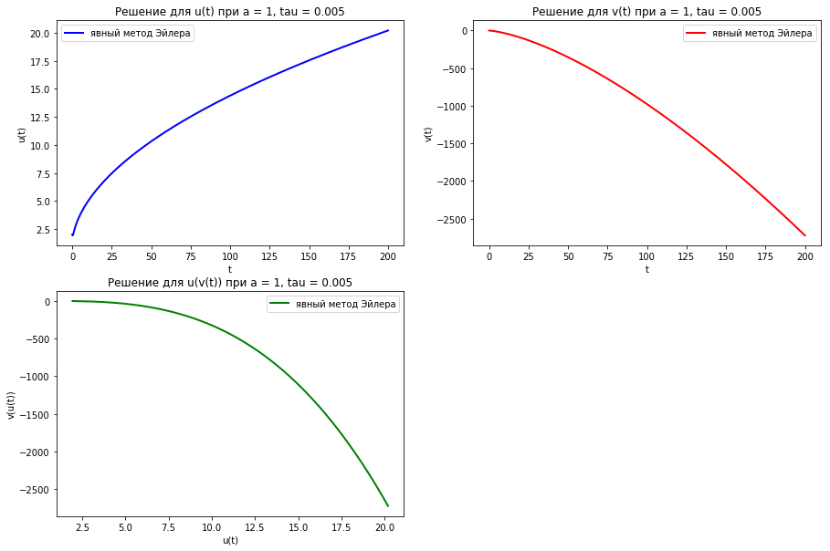

```python
%matplotlib inline
import numpy as np
from matplotlib import pyplot as plt
import math

# drawing improvements
fig_size = plt.rcParams["figure.figsize"]
fig_size[0] = 15 #width
fig_size[1] = 5*2 #height
plt.rcParams["figure.figsize"] = fig_size

# constants
t_min = 0
t_max = 200

# variables
a = 1
tau = 5*10**-3  # use only tau <= 5*10**-3 when a = 1 otherwise overflow error!

N = int((t_max - t_min) / tau)

u = np.zeros(N)
v = np.zeros(N)

u[0] = 2
v[0] = 0

for i in range(0, N-1):
    u[i+1] = u[i] - a * tau * (u[i]**3 / 3 - u[i]) - a * tau * v[i]
    v[i+1] = v[i] - tau * u[i]

t = np.linspace(t_min, t_max, num=N)

ax = plt.subplot(2,2,1)
plt.plot(t, u, color='blue', label='явный метод Эйлера', linewidth=2.0)
ax.set_title(f"Решение для u(t) при a = {a}, tau = {tau}")
ax.set_xlabel('t')
ax.set_ylabel('u(t)')
ax.legend()

ax = plt.subplot(2,2,2)
plt.plot(t, v, color='red', label='явный метод Эйлера', linewidth=2.0)
ax.set_title(f"Решение для v(t) при a = {a}, tau = {tau}")
ax.set_xlabel('t')
ax.set_ylabel('v(t)')
ax.legend()

ax = plt.subplot(2,2,3)
plt.plot(u, v, color='green', label='явный метод Эйлера', linewidth=2.0)
ax.set_title(f"Решение для u(v(t)) при a = {a}, tau = {tau}")
ax.set_xlabel('u(t)')
ax.set_ylabel('v(u(t))')
ax.legend()


plt.savefig('images/a/1.1.main.png')
```

#### Графики решений при различных $a$

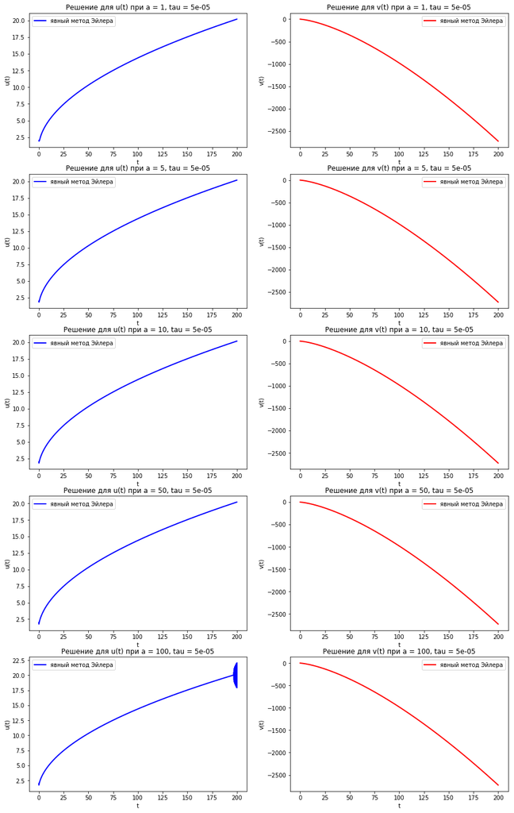

```python
%matplotlib inline
import numpy as np
from matplotlib import pyplot as plt
import math

# Different aas
aas = [10**0, 5*10**0, 10**1, 5*10**1, 10**2]

len_aas = len(aas)

# drawing improvements
fig_size = plt.rcParams["figure.figsize"]
fig_size[0] = 15 #width
fig_size[1] = 5*len_aas #height
plt.rcParams["figure.figsize"] = fig_size

# constants
t_min = 0
t_max = 200

# variables
tau = 5*10**-5  # use only tau <= 5*10**-3 otherwise overflow error!

cycles = 1
for a in aas:
    N = int((t_max - t_min) / tau)

    u = np.zeros(N)
    v = np.zeros(N)

    u[0] = 2
    v[0] = 0

    for i in range(0, N-1):
        u[i+1] = u[i] - a * tau * (u[i]**3 / 3 - u[i]) - a * tau * v[i]
        v[i+1] = v[i] - tau * u[i]

    t = np.linspace(t_min, t_max, num=N)

    ax = plt.subplot(len_aas,2,cycles)
    plt.plot(t, u, color='blue', label='явный метод Эйлера', linewidth=2.0)
    ax.set_title(f"Решение для u(t) при a = {a}, tau = {tau}")
    ax.set_xlabel('t')
    ax.set_ylabel('u(t)')
    ax.legend()

    ax = plt.subplot(len_aas,2,cycles+1)
    plt.plot(t, v, color='red', label='явный метод Эйлера', linewidth=2.0)
    ax.set_title(f"Решение для v(t) при a = {a}, tau = {tau}")
    ax.set_xlabel('t')
    ax.set_ylabel('v(t)')
    ax.legend()

    cycles += 2

plt.savefig('images/a/1.2.a.png')
```

#### Графики решений при различных $\tau$

Исследуем при каких $\tau$ будет наблюдаться сходимость. Функция устойчивости явного метода Эйлера:

\begin{equation*} R(z) = 1 + z, \; |R(z)| \leq 1 - критерий \: устойчивости. \end{equation*}

Тогда имеем:

\begin{equation*} |1 + z| \leq 1;\\ z = J \cdot \tau = \frac{df}{dy_1} \cdot \tau. \end{equation*}

У нас:

\begin{equation*} \frac{df}{dy_1} = - a ({y_1}^2 - 1);\\ |1 - a ({y_1}^2 - 1) \cdot \tau| \leq 1. \end{equation*}

Ранее при $a = 1, \: \tau = 5 \cdot 10^{-3}, \: y < 20$ неравенство выполнялось => имели устойчивую схему.

Функцию $g(y_1,y_2,\tau) = -y_1$ не рассматриваем, так как производная равна нулю и схема всегда устойчива.

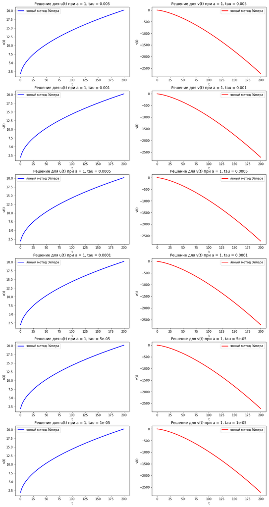

```python
%matplotlib inline
import numpy as np
from matplotlib import pyplot as plt
import math

# Different taus
taus = [5*10**-3, 10**-3, 5*10**-4, 10**-4, 5*10**-5, 10**-5]  # use only tau <= 5*10**-3 when a = 1 otherwise overflow error!

len_taus = len(taus)

# drawing improvements
fig_size = plt.rcParams["figure.figsize"]
fig_size[0] = 15 #width
fig_size[1] = 5*len_taus #height
plt.rcParams["figure.figsize"] = fig_size

# constants
t_min = 0
t_max = 200

# variables
a = 1

cycles = 1
for tau in taus:
    N = int((t_max - t_min) / tau)

    u = np.zeros(N)
    v = np.zeros(N)

    u[0] = 2
    v[0] = 0

    for i in range(0, N-1):
        u[i+1] = u[i] - a * tau * (u[i]**3 / 3 - u[i]) - a * tau * v[i]
        v[i+1] = v[i] - tau * u[i]

    t = np.linspace(t_min, t_max, num=N)

    ax = plt.subplot(len_taus,2,cycles)
    plt.plot(t, u, color='blue', label='явный метод Эйлера', linewidth=2.0)
    ax.set_title(f"Решение для u(t) при a = {a}, tau = {tau}")
    ax.set_xlabel('t')
    ax.set_ylabel('u(t)')
    ax.legend()

    ax = plt.subplot(len_taus,2,cycles+1)
    plt.plot(t, v, color='red', label='явный метод Эйлера', linewidth=2.0)
    ax.set_title(f"Решение для v(t) при a = {a}, tau = {tau}")
    ax.set_xlabel('t')
    ax.set_ylabel('v(t)')
    ax.legend()

    cycles += 2

plt.savefig('images/a/1.3.tau.png')
```

## 1.2. Уравнение Бонгоффера – Ван-дер-Поля

б) Уравнение Бонгоффера – Ван-дер-Поля:

\begin{equation*} \begin{cases} \frac{dy_1}{dt} = -a (\frac{y_{1}^3}{3} - y_1) + a y_2,\\ \frac{dy_2}{dt} = -y_1 - b y_2 + c. \end{cases} \end{equation*}

Сделаем замену: $u = y_1, v = y_2$. Используем явный метод Эйлера:

\begin{equation*} u_{k+1} = u_k + \tau \cdot f(x_k, y_k). \end{equation*}

Исходную систему можно преобразовать к виду:

\begin{equation*} \begin{cases} \frac{u_{n+1} - u_n}{\tau} = -a (\frac{{u_n}^3}{3} - u_n) + a v_n,\\ \frac{v_{n+1} - v_n}{\tau} = -u_n - b v_n + c. \end{cases} \end{equation*}

Решая данную систему получим выражения вида: $u_{n+1} = f(u_n, v_n), v_{n+1} = g(u_n, v_n)$. Имеем линейную систему:

\begin{equation*} \begin{cases} u_{n+1} = u_n - a \tau (\frac{{u_n}^3}{3} - u_n) + a \tau v_n;\\ v_{n+1} = v_n - \tau \cdot (u_n + b v_n -c); \end{cases} \end{equation*}

и $u(0) = u_0 = 2, \; v(0) = v_0 = 0$. Получили искомые формулы решения системы.

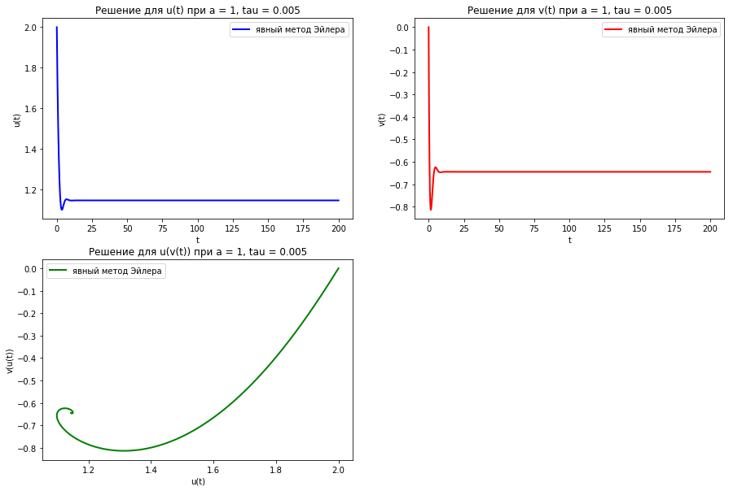

```python
%matplotlib inline
import numpy as np
from matplotlib import pyplot as plt
import math

# drawing improvements
fig_size = plt.rcParams["figure.figsize"]
fig_size[0] = 15 #width
fig_size[1] = 5*2 #height
plt.rcParams["figure.figsize"] = fig_size

# constants
t_min = 0
t_max = 200

# variables
a = 1
b = 1
c = 0.5
tau = 5*10**-3  # use only tau <= 5*10**-3 when a = 1 otherwise overflow error!

N = int((t_max - t_min) / tau)

u = np.zeros(N)
v = np.zeros(N)

u[0] = 2
v[0] = 0

for i in range(0, N-1):
    u[i+1] = u[i] - a * tau * (u[i]**3 / 3 - u[i]) + a * tau * v[i]
    v[i+1] = v[i] - tau * (u[i] + b * v[i] - c)

t = np.linspace(t_min, t_max, num=N)

ax = plt.subplot(2,2,1)
plt.plot(t, u, color='blue', label='явный метод Эйлера', linewidth=2.0)
ax.set_title(f"Решение для u(t) при a = {a}, tau = {tau}")
ax.set_xlabel('t')
ax.set_ylabel('u(t)')
ax.legend()

ax = plt.subplot(2,2,2)
plt.plot(t, v, color='red', label='явный метод Эйлера', linewidth=2.0)
ax.set_title(f"Решение для v(t) при a = {a}, tau = {tau}")
ax.set_xlabel('t')
ax.set_ylabel('v(t)')
ax.legend()

ax = plt.subplot(2,2,3)
plt.plot(u, v, color='green', label='явный метод Эйлера', linewidth=2.0)
ax.set_title(f"Решение для u(v(t)) при a = {a}, tau = {tau}")
ax.set_xlabel('u(t)')
ax.set_ylabel('v(u(t))')
ax.legend()


plt.savefig('images/b/1.1.main.png')
```

#### Графики решений при различных $a$

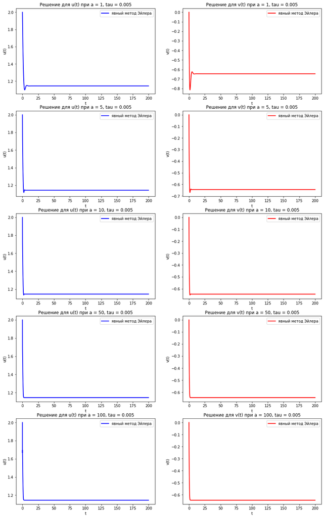

```python
%matplotlib inline
import numpy as np
from matplotlib import pyplot as plt
import math

# Different aas
aas = [10**0, 5*10**0, 10**1, 5*10**1, 10**2]

len_aas = len(aas)

# drawing improvements
fig_size = plt.rcParams["figure.figsize"]
fig_size[0] = 15 #width
fig_size[1] = 5*len_aas #height
plt.rcParams["figure.figsize"] = fig_size

# constants
t_min = 0
t_max = 200

# variables
b = 1
c = 0.5
tau = 5*10**-3  # use only tau <= 5*10**-3 otherwise overflow error!

cycles = 1
for a in aas:
    N = int((t_max - t_min) / tau)

    u = np.zeros(N)
    v = np.zeros(N)

    u[0] = 2
    v[0] = 0

    for i in range(0, N-1):
        u[i+1] = u[i] - a * tau * (u[i]**3 / 3 - u[i]) + a * tau * v[i]
        v[i+1] = v[i] - tau * (u[i] + b * v[i] - c)

    t = np.linspace(t_min, t_max, num=N)

    ax = plt.subplot(len_aas,2,cycles)
    plt.plot(t, u, color='blue', label='явный метод Эйлера', linewidth=2.0)
    ax.set_title(f"Решение для u(t) при a = {a}, tau = {tau}")
    ax.set_xlabel('t')
    ax.set_ylabel('u(t)')
    ax.legend()

    ax = plt.subplot(len_aas,2,cycles+1)
    plt.plot(t, v, color='red', label='явный метод Эйлера', linewidth=2.0)
    ax.set_title(f"Решение для v(t) при a = {a}, tau = {tau}")
    ax.set_xlabel('t')
    ax.set_ylabel('v(t)')
    ax.legend()

    cycles += 2

plt.savefig('images/b/1.2.a.png')
```

#### Графики решений при различных $\tau$

Исследуем при каких $\tau$ будет наблюдаться сходимость. Функция устойчивости явного метода Эйлера:

\begin{equation*} R(z) = 1 + z, \; |R(z)| \leq 1 - критерий \: устойчивости. \end{equation*}

Тогда имеем:

\begin{equation*} |1 + z| \leq 1;\\ z = J \cdot \tau = \frac{df}{dy_1} \cdot \tau. \end{equation*}

У нас:

\begin{equation*} \frac{df}{dy_1} = - a ({y_1}^2 - 1);\\ |1 - a ({y_1}^2 - 1) \cdot \tau| \leq 1. \end{equation*}

Ранее при $a = 1, \: \tau = 5 \cdot 10^{-3}, \: y < 2$ неравенство выполнялось => имели устойчивую схему.

Функция $g(y_1,y_2,\tau) = -y_1 - b y_2 + c$:

\begin{equation*} \frac{dg}{dy_2} = - b;\\ |1 - b \cdot \tau| \leq 1. \end{equation*}

Мы взяли $b = 1$ => схема устойчива.

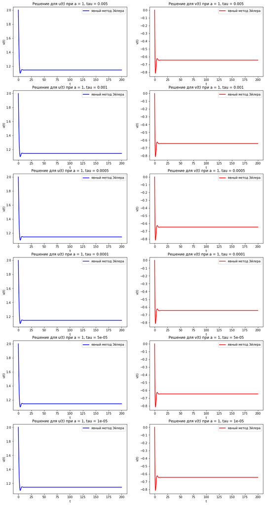

```python
%matplotlib inline
import numpy as np
from matplotlib import pyplot as plt
import math

# Different taus
taus = [5*10**-3, 10**-3, 5*10**-4, 10**-4, 5*10**-5, 10**-5]  # use only tau <= 5*10**-3 when a = 1 otherwise overflow error!

len_taus = len(taus)

# drawing improvements
fig_size = plt.rcParams["figure.figsize"]
fig_size[0] = 15 #width
fig_size[1] = 5*len_taus #height
plt.rcParams["figure.figsize"] = fig_size

# constants
t_min = 0
t_max = 200

# variables
a = 1
b = 1
c = 0.5

cycles = 1
for tau in taus:
    N = int((t_max - t_min) / tau)

    u = np.zeros(N)
    v = np.zeros(N)

    u[0] = 2
    v[0] = 0

    for i in range(0, N-1):
        u[i+1] = u[i] - a * tau * (u[i]**3 / 3 - u[i]) + a * tau * v[i]
        v[i+1] = v[i] - tau * (u[i] + b * v[i] - c)

    t = np.linspace(t_min, t_max, num=N)

    ax = plt.subplot(len_taus,2,cycles)
    plt.plot(t, u, color='blue', label='явный метод Эйлера', linewidth=2.0)
    ax.set_title(f"Решение для u(t) при a = {a}, tau = {tau}")
    ax.set_xlabel('t')
    ax.set_ylabel('u(t)')
    ax.legend()

    ax = plt.subplot(len_taus,2,cycles+1)
    plt.plot(t, v, color='red', label='явный метод Эйлера', linewidth=2.0)
    ax.set_title(f"Решение для v(t) при a = {a}, tau = {tau}")
    ax.set_xlabel('t')
    ax.set_ylabel('v(t)')
    ax.legend()

    cycles += 2

plt.savefig('images/b/1.3.tau.png')
```

## 1.3. Неавтономное уравнение Ван-дер-Поля, траектория-«утка»

в) Неавтономное уравнение Ван-дер-Поля, траектория-«утка»:

\begin{equation*} \begin{cases} \frac{dy_1}{dt} = -a (\frac{y_{1}^3}{3} - y_1) + a y_2,\\ \frac{dy_2}{dt} = -y_1 + A cos(\omega t). \end{cases} \end{equation*}

Сделаем замену: $u = y_1, v = y_2$. Используем явный метод Эйлера:

\begin{equation*} u_{k+1} = u_k + \tau \cdot f(x_k, y_k). \end{equation*}

Исходную систему можно преобразовать к виду:

\begin{equation*} \begin{cases} \frac{u_{n+1} - u_n}{\tau} = -a (\frac{{u_n}^3}{3} - u_n) + a v_n,\\ \frac{v_{n+1} - v_n}{\tau} = -u_n + A cos(\omega t). \end{cases} \end{equation*}

Решая данную систему получим выражения вида: $u_{n+1} = f(u_n, v_n), v_{n+1} = g(u_n, v_n)$. Имеем линейную систему:

\begin{equation*} \begin{cases} u_{n+1} = u_n - a \tau (\frac{{u_n}^3}{3} - u_n) + a \tau v_n;\\ v_{n+1} = v_n - \tau \cdot (u_n - A cos(\omega t)); \end{cases} \end{equation*}

и $u(0) = u_0 = 2, \; v(0) = v_0 = 0$. Получили искомые формулы решения системы.

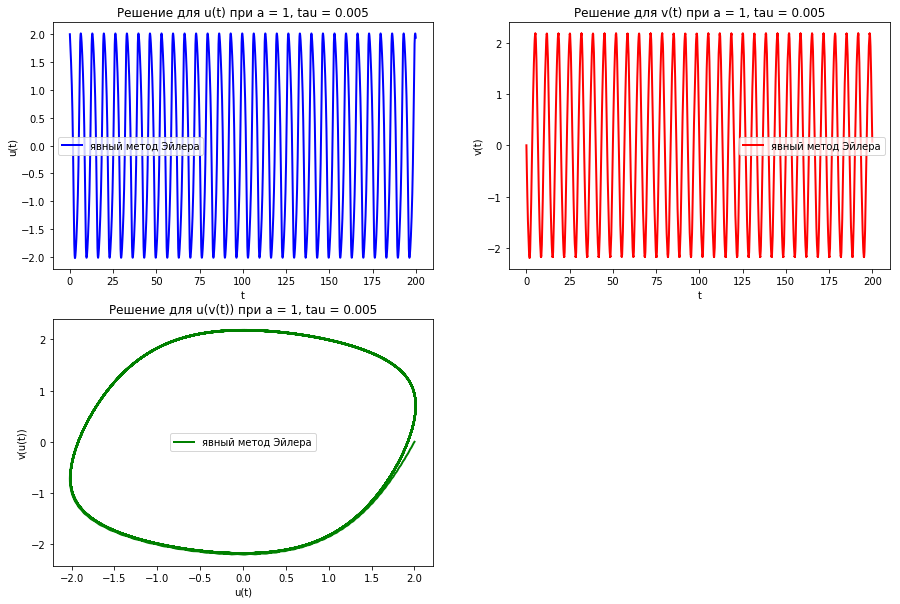

```python
%matplotlib inline
import numpy as np
from matplotlib import pyplot as plt
import math

# drawing improvements
fig_size = plt.rcParams["figure.figsize"]
fig_size[0] = 15 #width
fig_size[1] = 5*2 #height
plt.rcParams["figure.figsize"] = fig_size

# constants
t_min = 0
t_max = 200

# variables
a = 1
A = 0.5
omega = 100
tau = 5*10**-3  # use only tau <= 5*10**-3 when a = 1 otherwise overflow error!

N = int((t_max - t_min) / tau)

u = np.zeros(N)
v = np.zeros(N)

u[0] = 2
v[0] = 0

for i in range(0, N-1):
    t = (i + 1) * tau
    u[i+1] = u[i] - a * tau * (u[i]**3 / 3 - u[i]) + a * tau * v[i]
    v[i+1] = v[i] - tau * (u[i] - A * math.cos(omega * t))

t = np.linspace(t_min, t_max, num=N)

ax = plt.subplot(2,2,1)
plt.plot(t, u, color='blue', label='явный метод Эйлера', linewidth=2.0)
ax.set_title(f"Решение для u(t) при a = {a}, tau = {tau}")
ax.set_xlabel('t')
ax.set_ylabel('u(t)')
ax.legend()

ax = plt.subplot(2,2,2)
plt.plot(t, v, color='red', label='явный метод Эйлера', linewidth=2.0)
ax.set_title(f"Решение для v(t) при a = {a}, tau = {tau}")
ax.set_xlabel('t')
ax.set_ylabel('v(t)')
ax.legend()

ax = plt.subplot(2,2,3)
plt.plot(u, v, color='green', label='явный метод Эйлера', linewidth=2.0)
ax.set_title(f"Решение для u(v(t)) при a = {a}, tau = {tau}")
ax.set_xlabel('u(t)')
ax.set_ylabel('v(u(t))')
ax.legend()


plt.savefig('images/c/1.1.main.png')
```

#### Графики решений при различных $\omega$

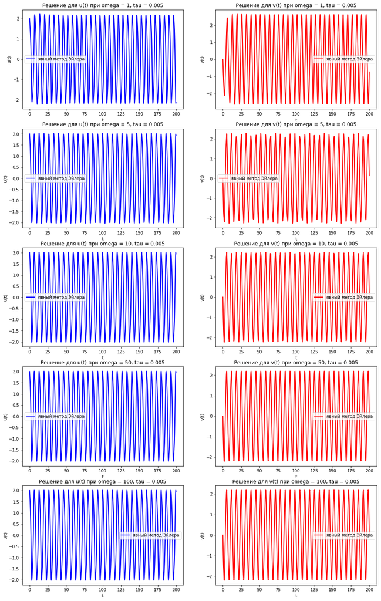

```python
%matplotlib inline
import numpy as np
from matplotlib import pyplot as plt
import math

# Different omegas
omegas = [10**0, 5*10**0, 10**1, 5*10**1, 10**2]

len_omegas = len(omegas)

# drawing improvements
fig_size = plt.rcParams["figure.figsize"]
fig_size[0] = 15 #width
fig_size[1] = 5*len_omegas #height
plt.rcParams["figure.figsize"] = fig_size

# constants
t_min = 0
t_max = 200

# variables
a = 1
A = 0.5
tau = 5*10**-3  # use only tau <= 5*10**-3 otherwise overflow error!

cycles = 1
for omega in omegas:
    N = int((t_max - t_min) / tau)

    u = np.zeros(N)
    v = np.zeros(N)

    u[0] = 2
    v[0] = 0

    for i in range(0, N-1):
        t = (i + 1) * tau
        u[i+1] = u[i] - a * tau * (u[i]**3 / 3 - u[i]) + a * tau * v[i]
        v[i+1] = v[i] - tau * (u[i] - A * math.cos(omega * t))

    t = np.linspace(t_min, t_max, num=N)

    ax = plt.subplot(len_omegas,2,cycles)
    plt.plot(t, u, color='blue', label='явный метод Эйлера', linewidth=2.0)
    ax.set_title(f"Решение для u(t) при omega = {omega}, tau = {tau}")
    ax.set_xlabel('t')
    ax.set_ylabel('u(t)')
    ax.legend()

    ax = plt.subplot(len_omegas,2,cycles+1)
    plt.plot(t, v, color='red', label='явный метод Эйлера', linewidth=2.0)
    ax.set_title(f"Решение для v(t) при omega = {omega}, tau = {tau}")
    ax.set_xlabel('t')
    ax.set_ylabel('v(t)')
    ax.legend()

    cycles += 2

plt.savefig('images/c/1.2.omega.png')
```

#### Графики решений при различных $\tau$

Меняется только функция $g(y_1,y_2,\tau)$. Аналогично 1.2. можно получить условия устойчивости.

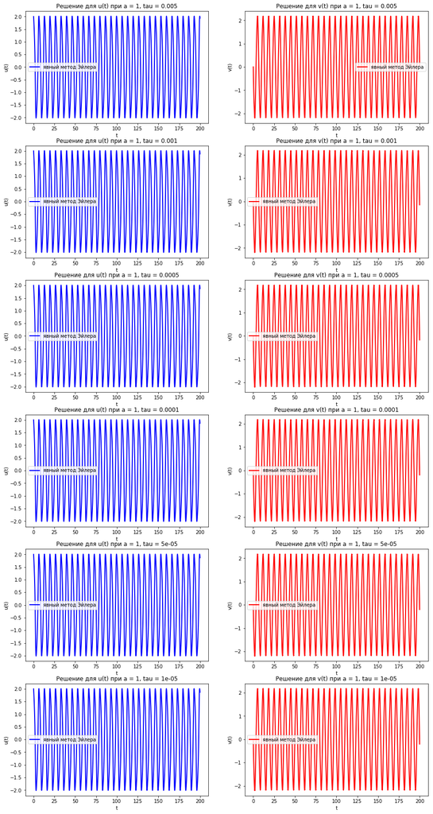

```python
%matplotlib inline
import numpy as np
from matplotlib import pyplot as plt
import math

# Different taus
taus = [5*10**-3, 10**-3, 5*10**-4, 10**-4, 5*10**-5, 10**-5]  # use only tau <= 5*10**-3 when a = 1 otherwise overflow error!

len_taus = len(taus)

# drawing improvements
fig_size = plt.rcParams["figure.figsize"]
fig_size[0] = 15 #width
fig_size[1] = 5*len_taus #height
plt.rcParams["figure.figsize"] = fig_size

# constants
t_min = 0
t_max = 200

# variables
a = 1
A = 0.5
omega = 100

cycles = 1
for tau in taus:
    N = int((t_max - t_min) / tau)

    u = np.zeros(N)
    v = np.zeros(N)

    u[0] = 2
    v[0] = 0

    for i in range(0, N-1):
        t = (i + 1) * tau
        u[i+1] = u[i] - a * tau * (u[i]**3 / 3 - u[i]) + a * tau * v[i]
        v[i+1] = v[i] - tau * (u[i] - A * math.cos(omega * t))

    t = np.linspace(t_min, t_max, num=N)

    ax = plt.subplot(len_taus,2,cycles)
    plt.plot(t, u, color='blue', label='явный метод Эйлера', linewidth=2.0)
    ax.set_title(f"Решение для u(t) при a = {a}, tau = {tau}")
    ax.set_xlabel('t')
    ax.set_ylabel('u(t)')
    ax.legend()

    ax = plt.subplot(len_taus,2,cycles+1)
    plt.plot(t, v, color='red', label='явный метод Эйлера', linewidth=2.0)
    ax.set_title(f"Решение для v(t) при a = {a}, tau = {tau}")
    ax.set_xlabel('t')
    ax.set_ylabel('v(t)')
    ax.legend()

    cycles += 2

plt.savefig('images/c/1.3.tau.png')
```

## 1.4. Уравнение Рэлея

г) Уравнение Рэлея:

\begin{equation*} x'' - a (1 - {x'}^2)x' + x = 0. \end{equation*}

Используем явный метод Эйлера:

\begin{equation*} u_{k+1} = u_k + \tau \cdot f(x_k, y_k). \end{equation*}

Исходную систему можно преобразовать к виду:

\begin{equation*} \begin{cases} x' = y,\\ y' - a (1-y^2)y + x = 0. \end{cases} \end{equation*}

Сделаем замену: $u = x, v = x'$.

\begin{equation*} \begin{cases} \frac{u_{n+1} - u_n}{\tau} = v_n,\\ \frac{v_{n+1} - v_n}{\tau} = a (1-{v_n}^2)v_n - u_n. \end{cases} \end{equation*}

Решая данную систему получим выражения вида: $u_{n+1} = f(u_n, v_n), v_{n+1} = g(u_n, v_n)$. Имеем линейную систему:

\begin{equation*} \begin{cases} u_{n+1} = u_n + \tau v_n;\\ v_{n+1} = v_n + \tau a \cdot (1 - {v_n}^2) v_n - u_n; \end{cases} \end{equation*}

и $u(0) = u_0 = 2, \; v(0) = v_0 = 0$. Получили искомые формулы решения системы.

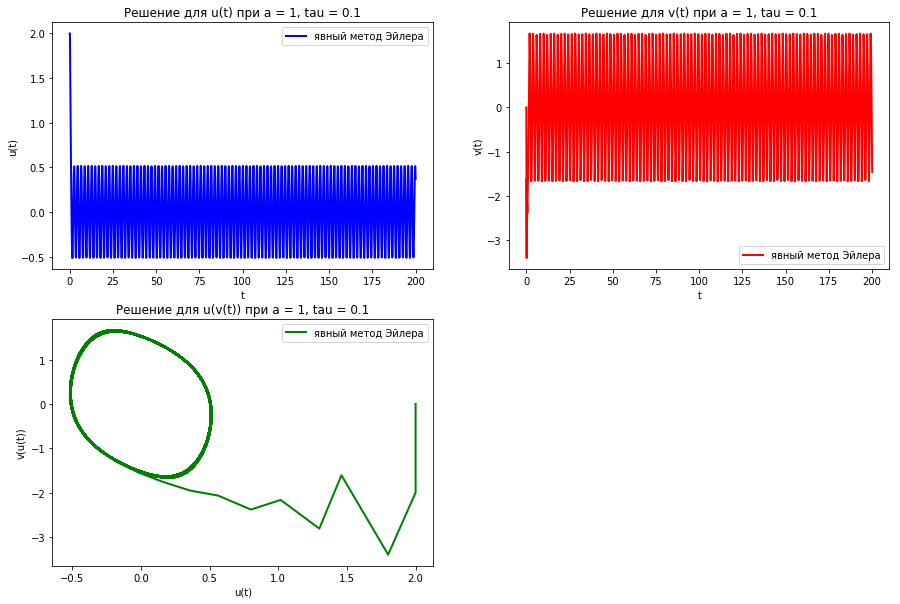

```python
%matplotlib inline
import numpy as np
from matplotlib import pyplot as plt
import math

# drawing improvements
fig_size = plt.rcParams["figure.figsize"]
fig_size[0] = 15 #width
fig_size[1] = 5*2 #height
plt.rcParams["figure.figsize"] = fig_size

# constants
t_min = 0
t_max = 200

# variables
a = 1
tau = 10**-1  # use only tau <= 5*10**-3 when a = 1 otherwise overflow error!

N = int((t_max - t_min) / tau)

u = np.zeros(N)
v = np.zeros(N)

u[0] = 2
v[0] = 0

for i in range(0, N-1):
    u[i+1] = u[i] + tau * v[i]
    v[i+1] = v[i] + tau * a * (1 - v[i]**2) * v[i] - u[i]

t = np.linspace(t_min, t_max, num=N)

ax = plt.subplot(2,2,1)
plt.plot(t, u, color='blue', label='явный метод Эйлера', linewidth=2.0)
ax.set_title(f"Решение для u(t) при a = {a}, tau = {tau}")
ax.set_xlabel('t')
ax.set_ylabel('u(t)')
ax.legend()

ax = plt.subplot(2,2,2)
plt.plot(t, v, color='red', label='явный метод Эйлера', linewidth=2.0)
ax.set_title(f"Решение для v(t) при a = {a}, tau = {tau}")
ax.set_xlabel('t')
ax.set_ylabel('v(t)')
ax.legend()

ax = plt.subplot(2,2,3)
plt.plot(u, v, color='green', label='явный метод Эйлера', linewidth=2.0)
ax.set_title(f"Решение для u(v(t)) при a = {a}, tau = {tau}")
ax.set_xlabel('u(t)')
ax.set_ylabel('v(u(t))')
ax.legend()


plt.savefig('images/d/1.1.main.png')
```

#### Графики решений при различных $a$

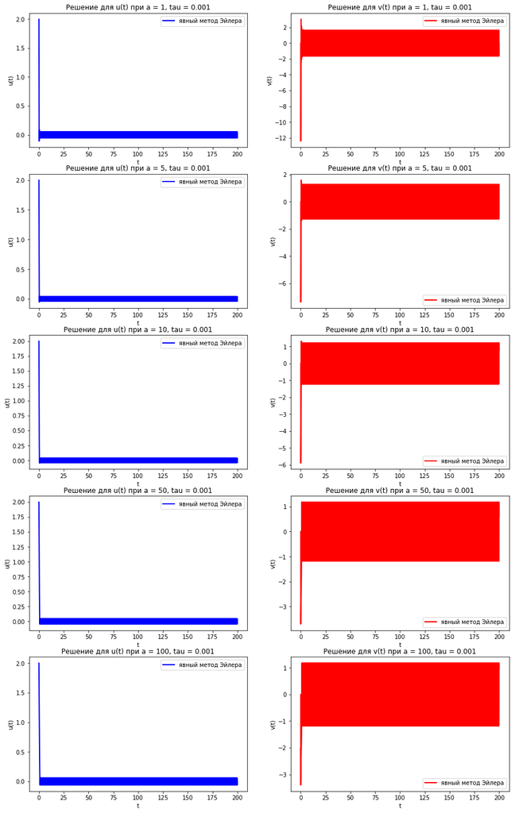

```python
%matplotlib inline
import numpy as np
from matplotlib import pyplot as plt
import math

# Different aas
aas = [10**0, 5*10**0, 10**1, 5*10**1, 10**2]

len_aas = len(aas)

# drawing improvements
fig_size = plt.rcParams["figure.figsize"]
fig_size[0] = 15 #width
fig_size[1] = 5*len_aas #height
plt.rcParams["figure.figsize"] = fig_size

# constants
t_min = 0
t_max = 200

# variables
tau = 10**-3  # use only tau <= 5*10**-3 otherwise overflow error!

cycles = 1
for a in aas:
    N = int((t_max - t_min) / tau)

    u = np.zeros(N)
    v = np.zeros(N)

    u[0] = 2
    v[0] = 0

    for i in range(0, N-1):
        u[i+1] = u[i] + tau * v[i]
        v[i+1] = v[i] + tau * a * (1 - v[i]**2) * v[i] - u[i]

    t = np.linspace(t_min, t_max, num=N)

    ax = plt.subplot(len_aas,2,cycles)
    plt.plot(t, u, color='blue', label='явный метод Эйлера', linewidth=2.0)
    ax.set_title(f"Решение для u(t) при a = {a}, tau = {tau}")
    ax.set_xlabel('t')
    ax.set_ylabel('u(t)')
    ax.legend()

    ax = plt.subplot(len_aas,2,cycles+1)
    plt.plot(t, v, color='red', label='явный метод Эйлера', linewidth=2.0)
    ax.set_title(f"Решение для v(t) при a = {a}, tau = {tau}")
    ax.set_xlabel('t')
    ax.set_ylabel('v(t)')
    ax.legend()

    cycles += 2

plt.savefig('images/d/1.2.a.png')
```

#### Графики решений при различных $\tau$

Исследуем при каких $\tau$ будет наблюдаться сходимость. Функция устойчивости явного метода Эйлера:

\begin{equation*} R(z) = 1 + z, \; |R(z)| \leq 1 - критерий \: устойчивости. \end{equation*}

Тогда имеем:

\begin{equation*} |1 + z| \leq 1;\\ z = J \cdot \tau = \frac{dg}{dv} \cdot \tau. \end{equation*}

У нас:

\begin{equation*} g = a(1-v^2)v - u;\\ \frac{dg}{dv} = a - 3 a v;\\ |1 + a (1 - 3 v) \cdot \tau| \leq 1. \end{equation*}

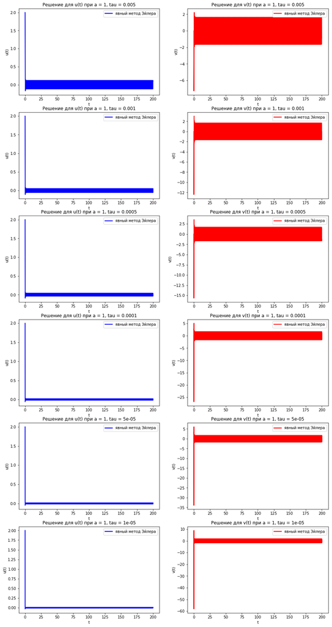

```python
%matplotlib inline
import numpy as np
from matplotlib import pyplot as plt
import math

# Different taus
taus = [5*10**-3, 10**-3, 5*10**-4, 10**-4, 5*10**-5, 10**-5]  # use only tau <= 5*10**-3 when a = 1 otherwise overflow error!

len_taus = len(taus)

# drawing improvements
fig_size = plt.rcParams["figure.figsize"]
fig_size[0] = 15 #width
fig_size[1] = 5*len_taus #height
plt.rcParams["figure.figsize"] = fig_size

# constants
t_min = 0
t_max = 200

# variables
a = 1

cycles = 1
for tau in taus:
    N = int((t_max - t_min) / tau)

    u = np.zeros(N)
    v = np.zeros(N)

    u[0] = 2
    v[0] = 0

    for i in range(0, N-1):
        u[i+1] = u[i] + tau * v[i]
        v[i+1] = v[i] + tau * a * (1 - v[i]**2) * v[i] - u[i]

    t = np.linspace(t_min, t_max, num=N)

    ax = plt.subplot(len_taus,2,cycles)
    plt.plot(t, u, color='blue', label='явный метод Эйлера', linewidth=2.0)
    ax.set_title(f"Решение для u(t) при a = {a}, tau = {tau}")
    ax.set_xlabel('t')
    ax.set_ylabel('u(t)')
    ax.legend()

    ax = plt.subplot(len_taus,2,cycles+1)
    plt.plot(t, v, color='red', label='явный метод Эйлера', linewidth=2.0)
    ax.set_title(f"Решение для v(t) при a = {a}, tau = {tau}")
    ax.set_xlabel('t')
    ax.set_ylabel('v(t)')
    ax.legend()

    cycles += 2

plt.savefig('images/d/1.3.tau.png')
```

### Изучение максимальной точности числа в Python

```python
import numpy as np
np.seterr(all='warn')
print("Range of numpy double:", np.finfo(np.double).min, np.finfo(np.double).max)
A = np.array([143],dtype='double')
a=A[-1]
print("At the border:", a**a)
B = np.array([144],dtype='double')
b=B[-1]
print("Blowing out of range:", b**3)
```

[output not shown]